# Introduction

Introduction to NLP — MSc. DH ENC-PSL

Noé Durandard (noe.durandard@psl.eu)

September 30, 2026

# 1 Natural Language

## 1.1 What is Natural Language?

### 1.1.1 Definition

**Natural Language**

A language that has evolved organically in a community, as a method of communicating between people.

- Modalities: Spoken, Written, Signed
- Examples: English, French, Arabic, Chinese, Samoan, ASL, etc.

### 1.1.2 In opposition to *Formal Language*

A **formal languages** is a set of finite symbols (strings) *designed* to avoid ambiguity.

- Examples: programming languages (e.g.; Python), mathematical notations, chemical formulas, etc.

**Core NLP challenge**

Use deterministic code (formal) to process fluid, non-deterministic natural language.

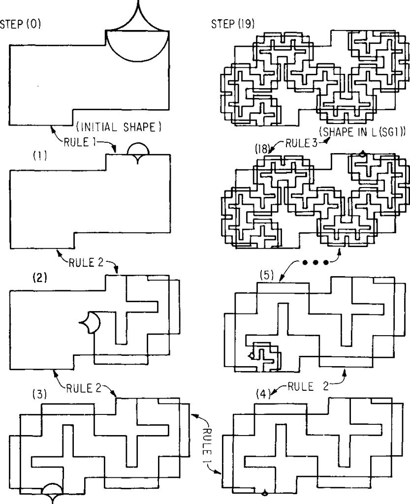

Generative specification of Stiny and Gips (1971)’s paintings class. *Fig 6-1 extracted from (Stiny and Gips 1971)*.

## 1.2 Linguistics (crash course)

### 1.2.1 Levels of Linguistic Analysis & Ambiguity

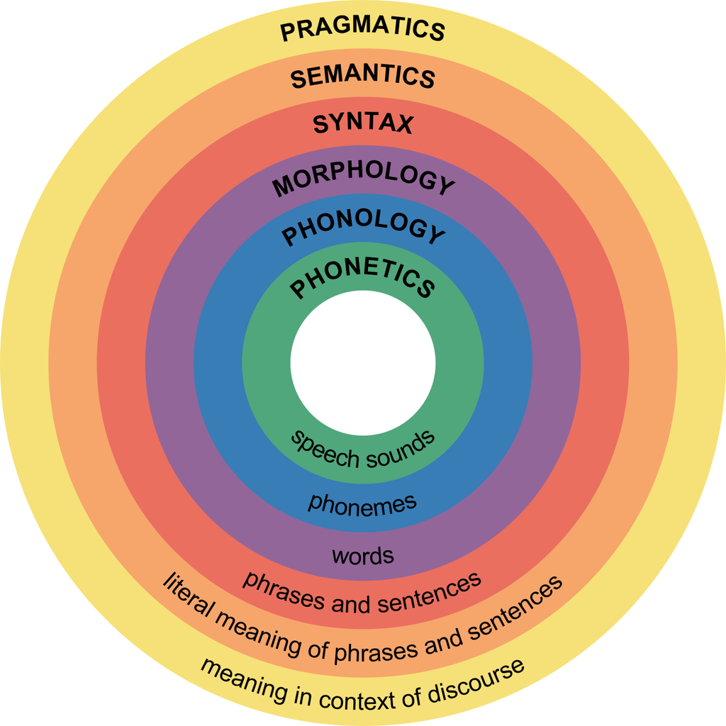

Major levels of linguistic structure. *James J. Thomas and Kristin A. Cook (Ed.) derivative work McSush, via Wikimedia commons.*

- Linguistic analysis can be decomposed into a hierarchy of several levels.
- Each level reveals different aspects of language.
- Ambiguity exists at every level!

### 1.2.2 Phonology

**Focus**: System of sounds (*phonemes*) and their representations.

**Examples**:

- “ɡˈɪv ˈpiːz ˈeɪ ˈtʃans !” vs. “ɡˈɪv ˈpiːs ˈeɪ ˈtʃans !” (IPA transcripts)
- “Un éléphant, marrant”

[interactive chart not shown]

  (see also Mondegreen)

**NLP tasks**: Speech Recognition, Text-to-Speech (TTS)

### 1.2.3 Morphology

**Focus**: Formation and internal structure of words, how smaller units of meaning (*morphemes*) combine.

**Examples**:

- unhappiness
- $\to\text{un-} + \text{happy} + \text{-ness}$
- untieable
- $\text{un-} + \text{[tie} + \text{-able]}$ vs. $\text{[un-} + \text{tie]} + \text{-able}$

**NLP tasks**: Lemmatization, stemming

### 1.2.4 Lexical / Part-of-Speech

**Focus**: study of the meaning and relationships of words

**Examples**:

- “*Time flies like an arrow; fruit flies like a banana.*” (Groucho Marx)
- “*I made her duck.*”

**NLP tasks**: Word Sense Disambiguation, Word embedding

### 1.2.5 Syntax

**Focus**: Sentence structure, rules for combining words into grammatical phrases.

**Examples**:

- I saw someone with a telescope.

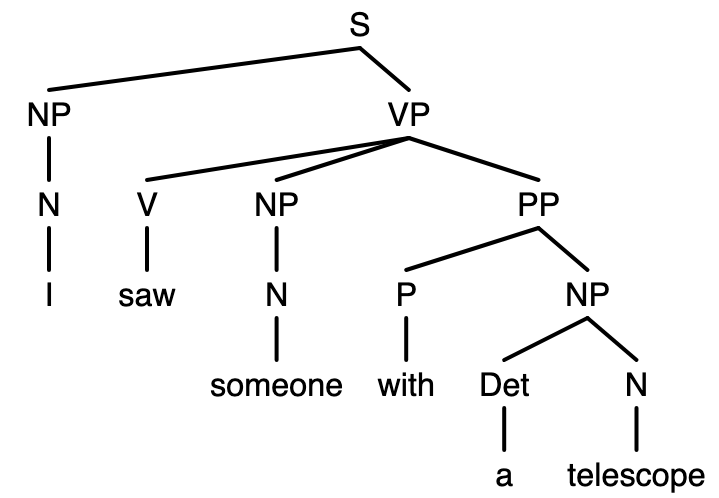

*Fig A1.11 and A1.12*

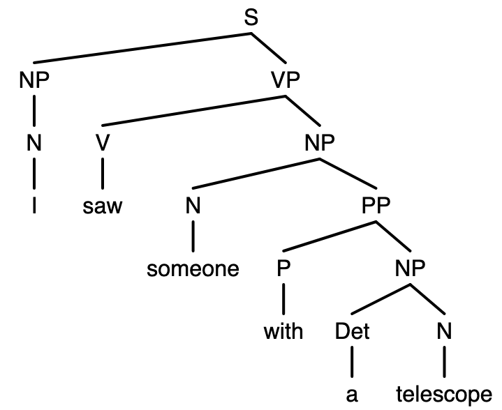

*from (Catherine Anderson 2022)*.

**NLP tasks**: Dependency parsing, POS-tagging

### 1.2.6 Semantics

**Focus**: the meaning in language, what is the message being communicated

**Examples**:

- “*In this country, a woman gives birth every 15 minutes….*
- *… Our job is to find that woman and stop her.*” (Groucho Marx)

**NLP tasks**: Natural Language Inference (NLI), broadly Natural Language Understanding (NLU)

### 1.2.7 Pragmatics

**Focus**: the way sentences with their semantic meanings are used for particular communicative goals

**Examples**:

- *Can you pass the salt?*

**NLP tasks**: dialogue systems, hate speech detection

## 1.3 Empirical behavior of NL

### 1.3.1 Content words & Function words

Vocabulary can be broadly split into two distinct functional classes:

| Class | Examples | Role | Statistical Behavior |
| --- | --- | --- | --- |
| **Function Words** | *the, of, and, in, to, is* | Grammatical relationships | High frequency, small fixed set (closed class) |
| **Content Words** | *language, happy, analyze* | Primary semantic meaning | Low frequency, unbounded set (open class) |

Note: most of the time we are not very interested in function words (stop-words), but they can also reveal interesting aspect (see Chung and Pennebaker 2011).

### 1.3.2 Zipf’s Law

**Zipf Law**

The frequency of a word ($f$) is inversely proportional to its rank ($r$): $f(r) \propto \frac{1}{r}$.

- **Top 10–20 words** account for up to **50% of all words** in a text.
- **The “Long Tail”:** most unique words occur only once or twice.

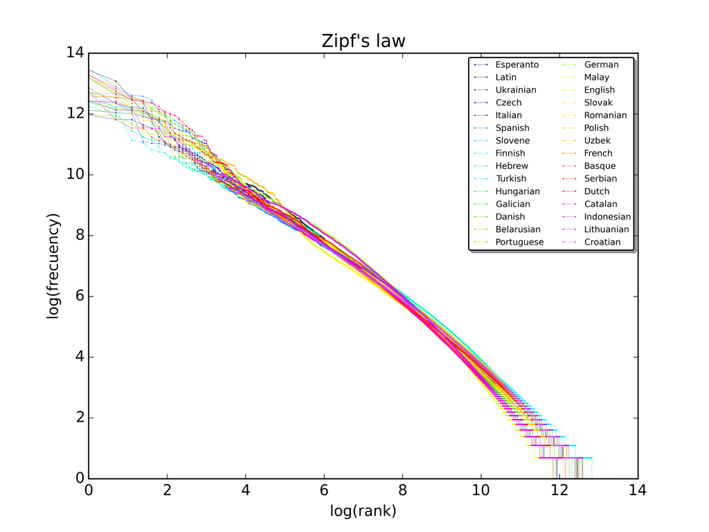

Zipf’s Law across languages. *SergioJimenez, via Wikimedia commons.*

## 1.4 So, why is NLP hard?

### 1.4.1 The Core Challenges

1. **Ambiguities** at every linguistic level of analysis
2. **Sparsity (Zipfian Tail):** most words are rare => most words (combinations) are new
3. **Infinite Expressivity:** infinite way to form sentences with a finite vocabulary
4. **Context Dependency:** meaning is rarely self-containe
5. **Linguistic Variation:** changes across time (diachronic), geography (dialects), social background (sociolects), mediums (tweets vs. news vs. spoken, vs. …)

# 2 Natural Language *Processing*

## 2.1 A quick history

### 2.1.1 Symbolic Era (~1950s-1990s)

#### 2.1.1.1 Rationalism

**Core Hypothesis**

Language is governed by explicit, mathematical, and generative grammar rules (Chomsky 1957).

- **Approach:** Hand-crafting dictionaries, morphological rules, and Context-Free Grammars (CFGs).

$\to$ Deductive reasoning: experts directly encode linguistic knowledge into rule-based computer programs.

#### 2.1.1.2 Important milestones

- Georgetown-IBM Experiment (1954)
  - Machine Translation
  - Translated 60 Russian sentences to English
  - Using 6 grammar rules and 250 vocabulary items.
- ELIZA (Weizenbaum, 1966)
  - Dialogue system
  - Pattern matching on words
  - `I need X` $\to$ `What would it mean to you if you got X?`

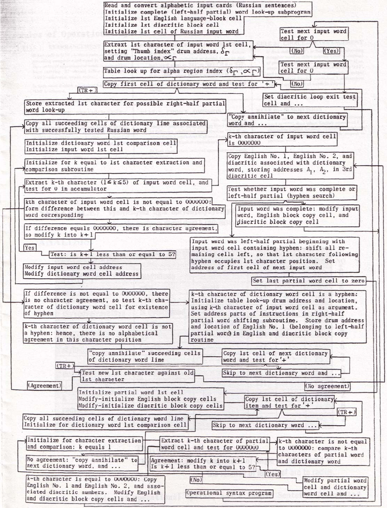

Flowchart of part of IBM 701 dictionary lookup procedure (Sheridan 1955), reproduced in (Hutchins 2005).

- “five, perhaps three years hence, interlingual meaning conversion by electronic process in important functional areas of several languages may well be an accomplished fact.” (Dr. Dostert, 1954)
- ELIZA effect

### 2.1.2 Statistical Era (~1990s-2010s)

#### 2.1.2.1 The Empiricist turn

*“Every time I fire a linguist, the performance of the speech recognizer goes up.”*  
— Fred Jelinek (IBM), 1988

**Paradigm Shift**

Move from hand-crafted expert rules to statistical/probabilistic approach: **counting events in large text corpora**.

Very influenced by *information-theoretic* view of language.

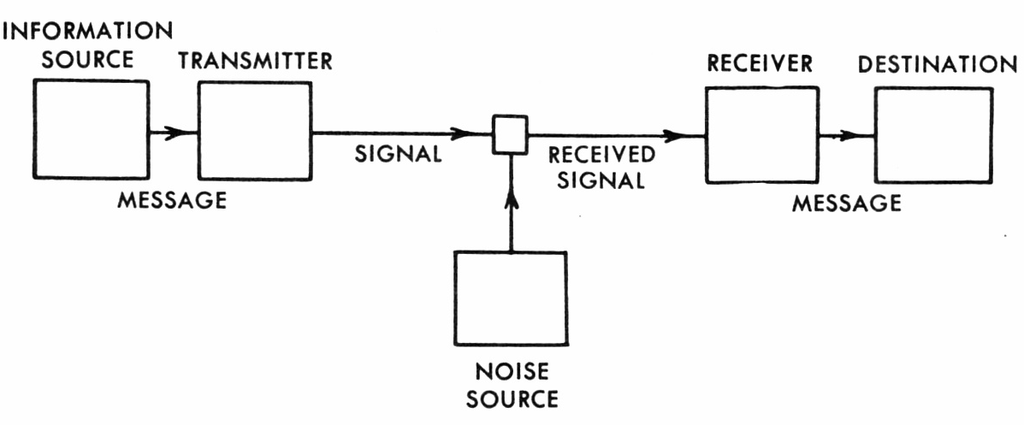

Shannon-Weaver model of communication (Shannon 1948).

#### 2.1.2.2 Classical Machine Learning and Feature-Engineering

- Statistical Machine Translation
- Classification tasks
- Discrete representation
- Rise of evaluation practices and benchmarking

$\to$ Feature-Engineering: practictioners determine discrete rules (features), ML handles the task

### 2.1.3 Neural Era (~2010s—)

The *AlexNet effect* (Krizhevsky, Sutskever, and Hinton 2012): sparked Deep Learning (DL) boom!

#### 2.1.3.1 Representation Learning

**Key Breakthrough**

Learning continuous, dense vector representations (**Embeddings**) end-to-end without manual feature extraction.

- Word2Vec (Mikolov et al. 2013): words = vectors
- Recurrent Neural Networks (RNNs): language is sequential, let’s process it that way (maintain a ‘hidden state’)

#### 2.1.3.2 The `transformer` revolution & foundation models

*“Attention is all you need”!* (Vaswani 2017)

- Introduction of “self-attention” mechanism (“look back” at specific parts of inputs at every steps)

$\to$ BERT (Devlin et al. 2019)

$\to$ GPT-series (Radford et al. 2018)

$\to$ etc.

**The era of foundation models**: Moving from single specialized models per task to massive, general-purpose (tunable) systems.

## 2.2 NLP in Practice

- Analysing words
  - POS-tagging, Named Entity Recognition, **Word Sense Disambiguation**, …
- Analysing sentences (to documents)
  - **Sentiment classification**, **Topic Modeling**, Natural Language Inference …
- Retrieving Information
  - Extracting information from document, **Ranking similar documents**, …
- Generating text content
  - **Completing Prompt, Filling blanks**, …
- Sequence to sequence generation
  - Machine Translation, Text Summarization, …

### 2.2.2 DH Applications

- Analyze style, authorship, ideology across corpora.
- Track semantic change over time.
- Support historical text restoration or OCR correction.
- Build metadata enrichment pipelines.
- Use models as *tools for exploration*, rather than oracles.
- …

[figure not shown]

Books

[figure not shown]

Newspapers

[figure not shown]

Subtitles

[figure not shown]

Patents

[figure not shown]

Tweets

… but also the other way around: **use DH to study LMs**.

# 3 NLP in this class

## 3.1 Content

### 3.1.1 Introduction to modern NLP models and methods:

- Language Representation
  - Tokenization, Word representations, Semantic Spaces
- Language Modeling
  - Foundations, n-grams, Transformer, Pre-trained Language Models
- Discovering Structure
  - Retrieval, Topic Modeling
- Inferring Patterns
  - Fine-tuning, Inference, Classification
- Generative LLMs*
  - Prompting, Automating, Evaluating

## 3.2 Logistics

### 3.2.1 Calendar

**No** class on:

- 28th of October
- 11th of November (non working day)

End of the class: 18th of November (included)

### 3.2.2 Material

Contact: noe.durandard@psl.eu

GitHub Repository: [d-noe/NLP_DH_F26](https://github.com/d-noe/NLP_DH_F26/)

Hands-On: Google Colab, Local Machines, Binder, …

### 3.2.3 References

- Always included at the end of the slides
  - some additional (optional) reading
- One book to rule them all: [*Speech and Language Processing*](https://web.stanford.edu/~jurafsky/slp3/), by Jurafsky and Martin (2026)
  - draft version freely accessible online

## 3.3 Assessment & Grading (T. Poibeau)

### 3.3.1 Practical & Critical Assignment

**Submission:** TBD (early- to mid- January 2027)

**Length:** ~5 pages (**7 max.**) · reasonable font & margins

Start from a **corpus** (preferably your **M2 thesis corpus**) and address a relevant **NLP/TAL question** with a clear objective.

1. **Implement** a solution  
   Existing code and/or your own approach · **justify your choices** · no off-the-shelf analysis
2. **Evaluate** the results  
   **Qualitative + quantitative** where appropriate · measures suited to the **question & data**
3. **Discuss critically**  
   Results & limitations · **alternatives, improvements & extensions**

### 3.3.2 Deliverables

> **Question → Solution → Justification → Evaluation → Critical discussion**

**Report:** ~5 pages · **7 max.**

**Bibliography:** short but compulsory · ≤ **5 references** · only sources **actually read**

**Presentation:** brief final-class presentation + questions on your **approach and results**

**Generative AI:** explicitly state **how it was used** and follow **school guidelines/charter + disciplinary best practices**

**Remember:**

**A fully finished solution is not absolutely required.**  
What matters is a **methodical, justified & critical approach**.

# 4 Modern NLP as an Empirical Science

## 4.1 NLP has become data-based

### 4.1.1 Reminder: The Empirist shift

- **Epistemic Shift:** Language processing becomes an inductive, data-driven science.
- **Hypothesis Testing & Evaluation:**
  - Models are trained (supervised, self-supervised, unsupervised) on corpus data.
  - System performance is measured against empirical benchmarks (*gold standards*).

### 4.1.2 Core scientifics objects

1. **Corpora:** The sampled collection of raw linguistic observations.
2. **Annotations:** The human-interpreted metadata and structural labels mapped onto text.

## 4.2 Corpus

### 4.2.1 Definition attempt

**Corpus (pl. corpora) — from (Pustejovsky and Stubbs 2012).**

a collection of **machine-readable texts** that have been produced in a **natural communicative setting**.

They have been **sampled** to be:

- *representative*, the content of the corpus can be generalized to that variety; and
- *balanced*, with respect to particular factors, for example by genre−newspaper articles, literary fiction, spoken speech, blogs and diaries, legal documents.

### 4.2.2 Text and beyond: multimodal corpora

Not much discussed in this class, but NLP also deals with, e.g.;

**Textual & Document Variants**

- **Historical Manuscripts:** OCR/HTR outputs containing visual layouts, noise, and script variations.
- **Social Media Data:** Interspersed with images, emojis, memes, and structural metadata.

**Beyond Text**

- **Spoken & Acoustic Transcripts:** Prosody, pauses, speaker alignments, and audio signals.
- **Vision-Language Corpora:** Images paired with captions or spatial bounding boxes.

### 4.2.3 Opportunistic vs. purpose-driven data collection

The construction of a NLP research project & corpora selection:

Corpus $\to$ RQ

1. Come across available data
2. Devise research question

RQ $\to$ Corpus

1. Start from a research question
2. Build an approriate corpus to tackle the RQ

2’) [Middle-ground:] look for appropriate data (+ expand)

### 4.2.4 Corpora are samples

- A corpus **cannot** represent the whole linguistic universe: finite sample shaped by availability, selection criteria, collection heuristics, etc.
- **Selection Bias:** These processes favor specific demographics, genres, historical moments, …

**Important**

Data is not a passive, objective reflection of the world. A corpus is a *constructed artifact* subject to sampling biases and human interpretation.

## 4.3 Annotation

### 4.3.1 Learning patterns require explicit labels

In **supervised machine learning**, algorithms learn mapping functions between input features ($\approx$corpus: $X$) and outputs (target labels: $Y$):
$$f(X) \rightarrow Y$$

**The fabrication of Truth?**

Most of the time, labels are created through human interpretation. “Gold Standard” or “Ground Truth” is a **socially constructed consensus**, rarely an objective physical property of the text.

### 4.3.2 Structural levels of annotations

- Word and subword level
  - (Morphological parsing)
  - (POS-tagging)
- Span level
  - Continuous (Named Entity Recognition (NER))
  - Discontinuous (Syntactic units, idiom components)
- Relational level
  - Directed relations (Relation extraction, Knowledge graphs)
  - Equivalence chains (Coreference resolution)
- Document level
  - (Sentiment analysis, Genre classification)

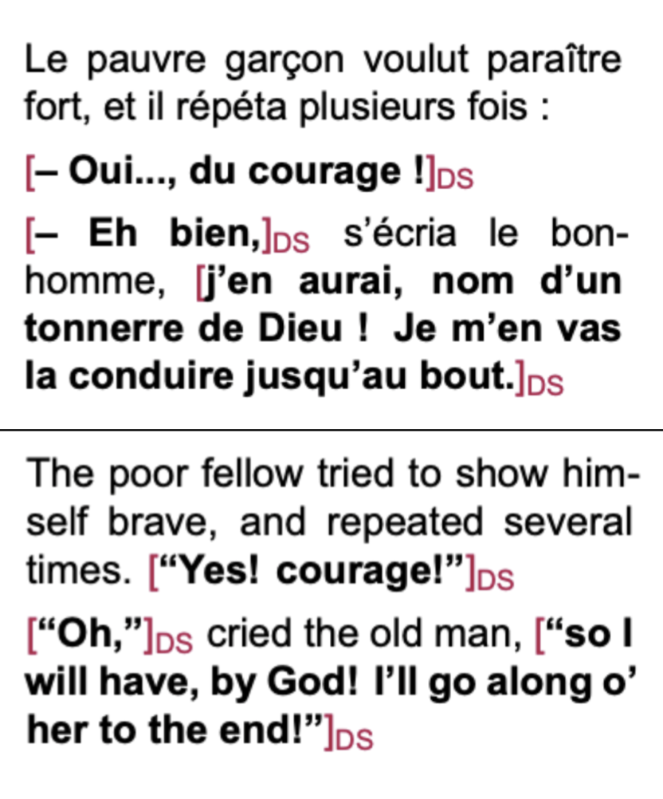

Excerpt of *Madame de Bovary* (Flaubert, 1856). *Extracted from (Durandard et al. 2023)*.

### 4.3.3 The annotation pipeline

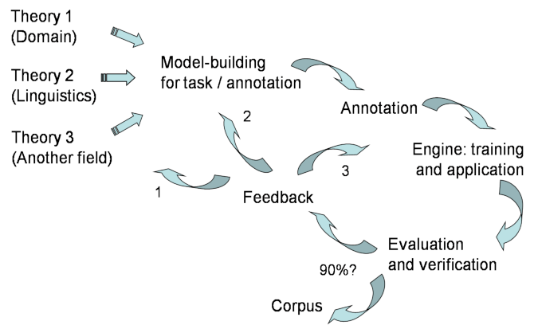

The generic annotation pipeline, extracted from (Hovy and Lavid 2010).

### 4.3.4 Interannotator agreement

**Cohen’s Kappa ($\kappa$)** measures agreement between *2 annotators* on categorical tasks, correcting for chance agreement:

$$\kappa = \frac{p_o - p_e}{1-p_e}$$

- $p_o$: observed agreement
- $p_e$: expected probability of agreement (how often would annotators agree assuming *independent* annotations)

### 4.3.5 Advance IAA & rule-of-thumb

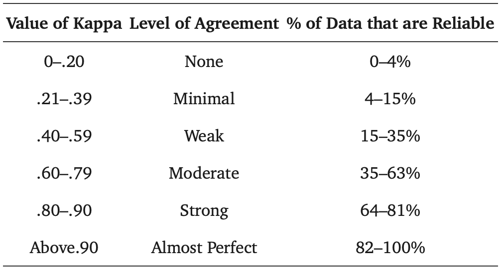

Rule of thumb to interpret IAA metrics. *Extracted from (McHugh 2012)*.

- **Fleiss’ Kappa:** Generalization of Cohen’s $\kappa$ for $>2$ annotators.
- **Krippendorff’s Alpha ($\alpha$):** Highly flexible metric handling multiple annotators, missing data, and different scale types (nominal, ordinal, interval).

## 4.4 [Workshop](https://github.com/d-noe/NLP_DH_F26/blob/main/code/1_introduction/Tutorial_1_Annotation.ipynb): Sentiment annotation

### 4.4.1 Annotation Manual

> Please read the instructions for the sentiment labelling task.

> You will see different sentences in the notebook. Your task is to decide whether each sentence has a *positive*, *negative*, *neutral* or *mixed* sentiment. For example, “*I like warm summer evenings*” has a *positive* sentiment.

> “*Mixed*” label refers to a sentence that has a mixed sentiment. For example, the sentence “*I liked the food, but the waiter was rude*” has a *mixed* sentiment.

> Try to be objective with your judgement.

### 4.4.2 Analysis

The data for the workshop actually comes from the study “Disambiguating sentiment annotation” (Äyräväinen, Hinds, and Davidson 2025).

**Further Reading on DH and Data annotation**

- (Stahel et al. 2025) on perspectivist annotation pipelines.
- (Krusic 2024) on constructing datasets with soft-label distributions.
- (Schmidt et al. 2019) on disagreement in literary text analysis.

### 4.4.3 Alternatives? *Data perspectivism*

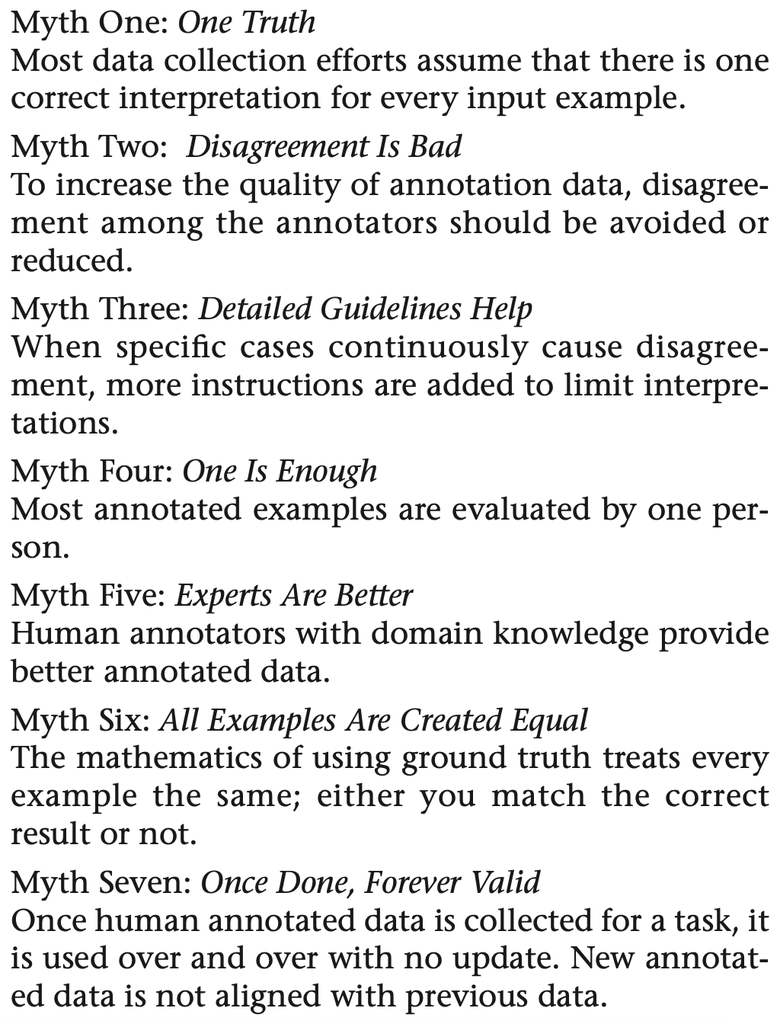

*The “Seven Myths” of data annotation, by Aroyo and Welty (2015).*

Recent developments challenge the traditional label-construction model.

**Data perspectivism** (Cabitza, Campagner, and Basile 2023):

- *soft labeling*: probabilistic labels (≠ hard, categorical labels)
- **disagreement = valuable data** (≠ error or noise)

> See also [perspectivist data manifesto](https://pdai.info), or workshops such as [NLPerspectives](https://nlperspectives.di.unito.it).

# 5 Tokenization

## 5.1 Motivation

### 5.1.1 The symbolic gap

- Computers do **not** process words, concepts, or historical nuances directly—they compute on **numbers, matrices, and vectors**.
- **Raw Text in Memory:** A continuous stream of Unicode bytes or ASCII characters.

### 5.1.2 Definition

**Tokenization**

the task of separating out or tokenizing words and word parts from running text. (Jurafsky and Martin 2026)

Process is:

Raw text $\to$ `tokenize` $\to$ Tokens decomposition $\to$ `vocabulary lookup` $\to$ Vocabulary IDs

### 5.1.3 Is it token=word?

$\to$ What is a *word*?

- cat
- I’m
  - one orthographically, two grammatically
- C U
- San Francisco
- what about languages with no separators?

Ill-defined, ambiguous and context dependent.

Not really, we’ll come back to that shortly (but for simplicity, you can think of token=words most of the time).

## 5.2 The universal first step

### 5.2.1 Always tokenize

Regardless of historical era or model paradigm, **tokenization is the gateway to every NLP pipeline**:

**Traditional NLP Pipeline**

```
[ Raw Text ]
     │
     ▼
[ Tokenization ]
     │
     ▼
[ Stopwords removal [?] ]
     │
     ▼
[ ... ]
```

- Discrete rule-based or statistical features.

**Modern Neural Pipeline**

```
[ Raw Text ]
     │
     ▼
[ Subword Tokenizer ]
     │
     ▼
[ Token ID Sequence ]
     │
     ▼
[ Dense Vector Embeddings ]
```

- Continuous vector spaces & Transformers.

### 5.2.2 Some useful libraries

Different libraries specialize in different tokenization paradigms:

| Library | Paradigm | Typical Level | Primary Use Case |
| --- | --- | --- | --- |
| `NLTK` | Rule-based & regex heuristics | Words / Sentences | classical NLP prototyping |
| `spaCy` | Dependency-aware tokenization | Words / Morphemes | Production linguistic pipelines (POS, NER) |
| `HuggingFace Tokenizers` | Subword statistical models | Subwords (BPE, WordPiece) | Fine-tuning Transformer models (BERT, RoBERTa) |
| `tiktoken` | Byte-Pair Encoding (BPE) | Subwords / Bytes | OpenAI LLM models (GPT-3.5, GPT-4o) |

## 5.3 ‘Word’-Tokenizers

### 5.3.1 Regex Pattern matching

Using regular expressions to isolate ‘words’ explicitly:

```python
import re
text = "The cat is on the mat, the dog isn't."
tokens = re.findall(r"\w+|[^\w\s]", text)
# Output: ['The', 'cat', 'is', 'on', 'the', 'mat', ',', 'the', 'dog', 'isn', "'", 't', '.']
```

Limitations: **Out-Of-Vocabulary** (OOV) issues, rely on **whitespace delimiters** (what about other languages: Chinese, Japanese, Ancient Greek *scriptio continua*, etc.?)

**Tip**

Note that such approaches are still the foundation pre-tokenization step of modern tokenizers!

## 5.4 Subword tokenization

### 5.4.1 Byte-Pair Encoding (BPE) (Gage 1994)

Directly learn from the data!

```python
function BYTE-PAIR ENCODINGS(C:string, vocab_size:int):
  V = [all unique bytes in C] # initial set of tokens is characters (bytes)

  learned_merges = [] # list of learned merges
  while len(V) < vocab_size: # expand vocab (merges) until reaching vocab_size
    (a, b) = get_most_frequent_pair(C) # most frequent adjacent pair
    new_token = a + b # make new token by concatenation
    V += [new_token]
    learned_merges += [(a,b), new_token]
    update(C, learned_merges) # update corpus: replace each occurence of (a, b) with new_token

  return V
```

## 5.5 [Hands-on Exercise](https://github.com/d-noe/NLP_DH_F26/blob/main/code/1_introduction/Hands_on_1_tokenization.ipynb)

# 6 Conclusion

## References

Aroyo, Lora, and Chris Welty. 2015. “Truth Is a Lie: Crowd Truth and the Seven Myths of Human Annotation.” *AI Magazine* 36 (1): 15–24.

Äyräväinen, Laura EM, Joanne Hinds, and Brittany I Davidson. 2025. “Disambiguating Sentiment Annotation: A Mixed Methods Investigation of Annotator Experience and Impact of Instructions on Annotator Agreement.” *Plos One* 20 (12): e0336269.

Cabitza, Federico, Andrea Campagner, and Valerio Basile. 2023. “Toward a Perspectivist Turn in Ground Truthing for Predictive Computing.” In *Proceedings of the AAAI Conference on Artificial Intelligence*, 37:6860–68. 6.

Catherine Anderson, Derek Denis, Bronwyn Bjorkman. 2022. *Essentials of Linguistics, 2nd Edition*. eCampusOntario Open Authoring Platform.

Chomsky, Noam. 1957. *Syntactic Structures*. Walter de Gruyter.

Chung, Cindy, and James Pennebaker. 2011. “The Psychological Functions of Function Words.” In *Social Communication*, 343–59. Psychology Press.

Devlin, Jacob, Ming-Wei Chang, Kenton Lee, and Kristina Toutanova. 2019. “BERT: Pre-Training of Deep Bidirectional Transformers for Language Understanding.” https://arxiv.org/abs/1810.04805.

Durandard, Noé, Viet Anh Tran, Gaspard Michel, and Elena Epure. 2023. “Automatic Annotation of Direct Speech in Written French Narratives.” In *Proceedings of the 61st Annual Meeting of the Association for Computational Linguistics (Volume 1: Long Papers)*, edited by Anna Rogers, Jordan Boyd-Graber, and Naoaki Okazaki, 7129–47. Toronto, Canada: Association for Computational Linguistics. https://doi.org/10.18653/v1/2023.acl-long.393.

Gage, Philip. 1994. “A New Algorithm for Data Compression.” *C Users Journal* 12 (2): 23–38.

Hovy, Eduard, and Julia Lavid. 2010. “Towards a ‘Science’of Corpus Annotation: A New Methodological Challenge for Corpus Linguistics.” *International Journal of Translation* 22 (1): 13–36.

Hutchins, John. 2005. “The First Public Demonstration of Machine Translation: The Georgetown-IBM System, 7th January 1954.” *Noviembre de*.

Jurafsky, Daniel, and James H. Martin. 2026. *Speech and Language Processing: An Introduction to Natural Language Processing, Computational Linguistics, and Speech Recognition, with Language Models*. 3rd ed. https://web.stanford.edu/~jurafsky/slp3/.

Krizhevsky, Alex, Ilya Sutskever, and Geoffrey E Hinton. 2012. “Imagenet Classification with Deep Convolutional Neural Networks.” *Advances in Neural Information Processing Systems* 25.

Krusic, Lucija. 2024. “Constructing a Sentiment-Annotated Corpus of Austrian Historical Newspapers: Challenges, Tools, and Annotator Experience.” In *Proceedings of the 4th International Conference on Natural Language Processing for Digital Humanities*, edited by Mika Hämäläinen, Emily Öhman, So Miyagawa, Khalid Alnajjar, and Yuri Bizzoni, 51–62. Miami, USA: Association for Computational Linguistics. https://doi.org/10.18653/v1/2024.nlp4dh-1.6.

McHugh, Mary L. 2012. “Interrater Reliability: The Kappa Statistic.” *Biochemia Medica* 22 (3): 276–82.

Mikolov, Tomas, Kai Chen, Greg Corrado, and Jeffrey Dean. 2013. “Efficient Estimation of Word Representations in Vector Space.” https://arxiv.org/abs/1301.3781.

Pustejovsky, James, and Amber Stubbs. 2012. *Natural Language Annotation for Machine Learning: A Guide to Corpus-Building for Applications*. " O’Reilly Media, Inc.".

Radford, Alec, Karthik Narasimhan, Tim Salimans, Ilya Sutskever, et al. 2018. “Improving Language Understanding by Generative Pre-Training.”

Schmidt, Thomas, Brigitte Winterl, Milena Maul, Alina Schark, Andrea Vlad, and Christian Wolff. 2019. “Inter-Rater Agreement and Usability: A Comparative Evaluation of Annotation Tools for Sentiment Annotation.” In *INFORMATIK 2019: 50 Jahre Gesellschaft Für Informatik – Informatik Für Gesellschaft (Workshop-Beiträge)*, edited by Claude Draude, Martin Lange, and Bernhard Sick, 121–33. Bonn: Gesellschaft für Informatik e.V. https://doi.org/10.18420/inf2019_ws12.

Shannon, Claude Elwood. 1948. “A Mathematical Theory of Communication.” *The Bell System Technical Journal* 27 (3): 379–423.

Sheridan, Peter. 1955. “Research in Language Translation on the IBM Type 701.” *IBM Technical Newsletter* 9: 5–24.

Stahel, Karin, Irenie How, Lauren Millar, Luis Paterson, Daniel Steel, and Kaspar Middendorf. 2025. “A Bit of This, a Bit of That: Building a Genre and Topic Annotated Dataset of Historical Newspaper Articles with Soft Labels and Confidence Scores.” In *Proceedings of the 5th International Conference on Natural Language Processing for Digital Humanities*, edited by Mika Hämäläinen, Emily Öhman, Yuri Bizzoni, So Miyagawa, and Khalid Alnajjar, 377–92. Albuquerque, USA: Association for Computational Linguistics. https://doi.org/10.18653/v1/2025.nlp4dh-1.33.

Stiny, George, and James Gips. 1971. “Shape Grammars and the Generative Specification of Painting and Sculpture.” In *IFIP Congress (2)*, 2:125–35. 3.

Vaswani, A. 2017. “Attention Is All You Need.” *Advances in Neural Information Processing Systems*. https://dl.acm.org/doi/10.5555/3295222.3295349.

Introduction

[figure not shown]